# Practical Machine Learning Assignment

Tarun

4/20/2021

##Introduction The goal of this project is to predict the manner in which they did the exercise. This is the “classe” variable in the training set.

# Data Setes Dtasetes are avialable on the belove-mentioned links:-

For tarining- https://d396qusza40orc.cloudfront.net/predmachlearn/pml-training.csv

For test- https://d396qusza40orc.cloudfront.net/predmachlearn/pml-testing.csv

I am going to use the below-mentioned R- Packages for the EDA, datacleaning and model buildings-

```r
 require(knitr)
 require(caret)
 require(rpart)
```

```r
 require(rpart.plot)
 require(randomForest)
 require(caTools)
 require(Amelia)
```

##Loading Data

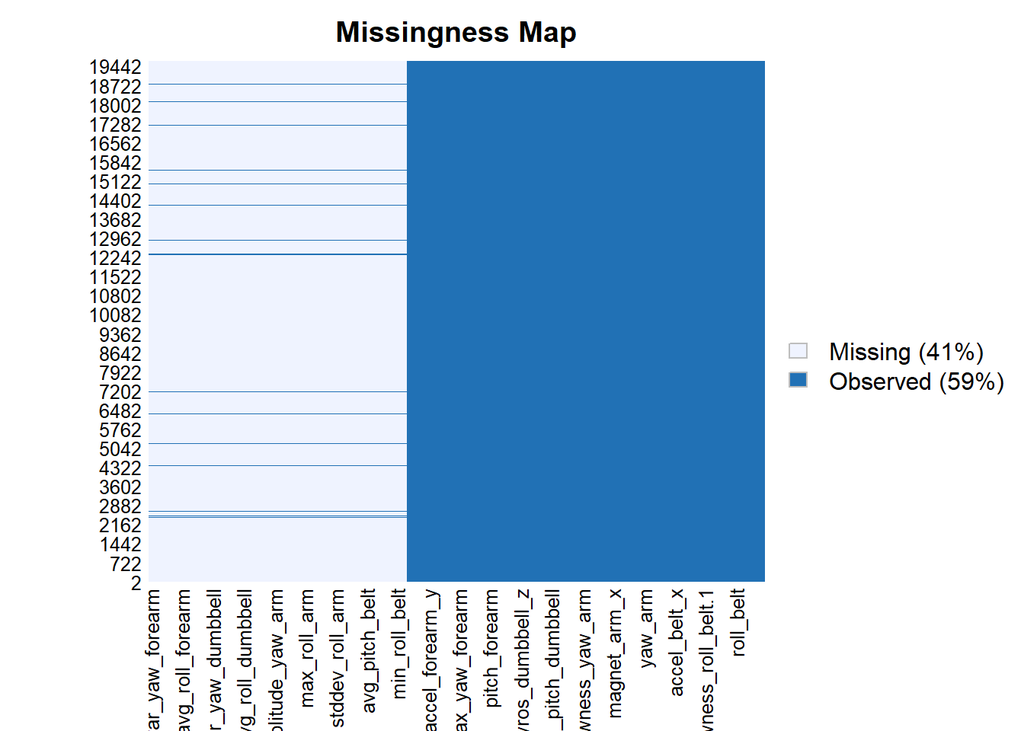

```r
# file.choose function help to load the data from anywhere in your system
tr_data <- read.csv(file.choose(),stringsAsFactors = T, header = T )
ts_data <- read.csv(file.choose(),stringsAsFactors = T, header = T )
missmap(tr_data) # To check the missing values
```

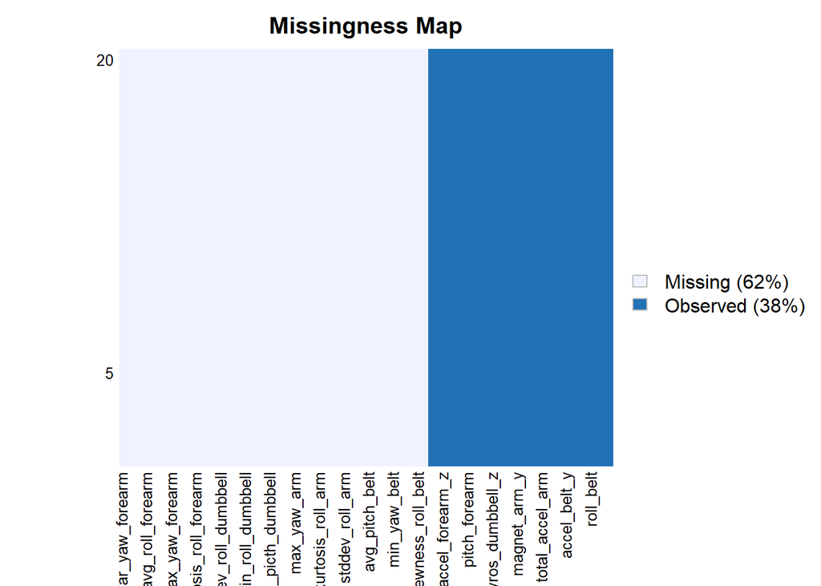

```r
missmap(ts_data)
```

```r
dim(tr_data)
```

```
## [1] 19622   160
```

```r
dim(ts_data)
```

```
## [1]  20 160
```

##Data Cleansing

```r
nzv <- nearZeroVar(tr_data)
tr_data <- tr_data[, -nzv]
ts_data <- ts_data[, -nzv]
dim(tr_data)
```

```
## [1] 19622   100
```

```r
dim(ts_data)
```

```
## [1]  20 100
```

```r
AllNA <- sapply(tr_data, function(x) mean(is.na(x))) > 0.95 #Removing Variables which are having NA values, Our threshhold is 95%
tr_data <- tr_data[, AllNA==FALSE]
dim(tr_data)
```

```
## [1] 19622    59
```

```r
ts_data <- ts_data[, AllNA==FALSE]
dim(ts_data)
```

```
## [1] 20 59
```

```r
#Removing the first 7 Variables which are Non-Numeric.
tr_data <- tr_data[, 8:59]
ts_data <- ts_data[, 8:59]
dim(tr_data)
```

```
## [1] 19622    52
```

```r
dim(ts_data)
```

```
## [1] 20 52
```

```r
colnames(tr_data)
```

```
##  [1] "pitch_belt"           "yaw_belt"             "total_accel_belt"
##  [4] "gyros_belt_x"         "gyros_belt_y"         "gyros_belt_z"
##  [7] "accel_belt_x"         "accel_belt_y"         "accel_belt_z"
## [10] "magnet_belt_x"        "magnet_belt_y"        "magnet_belt_z"
## [13] "roll_arm"             "pitch_arm"            "yaw_arm"
## [16] "total_accel_arm"      "gyros_arm_x"          "gyros_arm_y"
## [19] "gyros_arm_z"          "accel_arm_x"          "accel_arm_y"
## [22] "accel_arm_z"          "magnet_arm_x"         "magnet_arm_y"
## [25] "magnet_arm_z"         "roll_dumbbell"        "pitch_dumbbell"
## [28] "yaw_dumbbell"         "total_accel_dumbbell" "gyros_dumbbell_x"
## [31] "gyros_dumbbell_y"     "gyros_dumbbell_z"     "accel_dumbbell_x"
## [34] "accel_dumbbell_y"     "accel_dumbbell_z"     "magnet_dumbbell_x"
## [37] "magnet_dumbbell_y"    "magnet_dumbbell_z"    "roll_forearm"
## [40] "pitch_forearm"        "yaw_forearm"          "total_accel_forearm"
## [43] "gyros_forearm_x"      "gyros_forearm_y"      "gyros_forearm_z"
## [46] "accel_forearm_x"      "accel_forearm_y"      "accel_forearm_z"
## [49] "magnet_forearm_x"     "magnet_forearm_y"     "magnet_forearm_z"
## [52] "classe"
```

##Data Partitioning

For the cross validation or to check the accuracy of our model we need to divide training dataset further. For this i am foing to use CAtools package.

```r
sample = sample.split(tr_data, SplitRatio = .75)
train_dt = subset(tr_data, sample == TRUE)
test_dt  = subset(tr_data, sample == FALSE)
```

## Decision Tree Model

```r
set.seed(123)
fit <- rpart(classe ~ ., data = train_dt, method="class")
pred <- predict(fit,test_dt,type = "class")
confusionMatrix(pred,test_dt$classe)
```

```
## Confusion Matrix and Statistics
##
##           Reference
## Prediction    A    B    C    D    E
##          A 1231  142   15   46   54
##          B   30  482   44   60   25
##          C   21  144  668  130  225
##          D   95  112  110  516   39
##          E   17   70   20   51  558
##
## Overall Statistics
##
##                Accuracy : 0.7044
##                  95% CI : (0.6914, 0.7171)
##     No Information Rate : 0.2842
##     P-Value [Acc > NIR] : < 2.2e-16
##
##                   Kappa : 0.6259
##
##  Mcnemar's Test P-Value : < 2.2e-16
##
## Statistics by Class:
##
##                      Class: A Class: B Class: C Class: D Class: E
## Sensitivity            0.8831  0.50737   0.7795   0.6426   0.6193
## Specificity            0.9268  0.95980   0.8715   0.9132   0.9605
## Pos Pred Value         0.8273  0.75195   0.5623   0.5917   0.7793
## Neg Pred Value         0.9523  0.89024   0.9492   0.9288   0.9181
## Prevalence             0.2842  0.19368   0.1747   0.1637   0.1837
## Detection Rate         0.2510  0.09827   0.1362   0.1052   0.1138
## Detection Prevalence   0.3034  0.13068   0.2422   0.1778   0.1460
## Balanced Accuracy      0.9049  0.73358   0.8255   0.7779   0.7899
```

As we can see that accuracy lavel of decision tree is 70%,which is not upto the desired level. So we need to check other models to compare the accuracy with this model.

##Random Forest Model

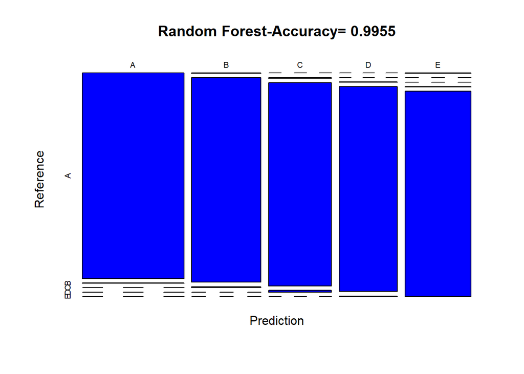

```r
set.seed(123)
rf_fit <- randomForest(classe ~ ., data = train_dt,mtyr=7)
rf_pred <- predict(rf_fit,test_dt)
cnf_rf <- confusionMatrix(rf_pred,test_dt$classe)
        plot(cnf_rf$table,col =cnf_rf$byClass,color="blue",main=paste("Random Forest-Accuracy=",
                        round(cnf_rf$overall['Accuracy'], 4)))
```

After checking the Overall Statistics data, the Random Forest model has definitely more accuracy than Decision tree model. Hence we will be selecting Random Forest model for final prediction

```r
rf_ts_pred <- predict(rf_fit,ts_data)
rf_ts_pred
```

```
##  1  2  3  4  5  6  7  8  9 10 11 12 13 14 15 16 17 18 19 20
##  B  A  B  A  A  E  D  B  A  A  B  C  B  A  E  E  A  B  B  B
## Levels: A B C D E
```